# Roll No - 23110098

## Prerequisite Test

### QUE 1 How many multiplications and additions do you need to perform a matrix multiplication between a (n, k) and (k, m) matrix? Explain.

In matrix multiplication multiplication happens n * k * m times and addition happens n * (k-1) * m times.

As in the matrix multiplication for finding the ans[i][j] (where 1<=i<=n and 1<=j<=m) we do multiplication k times and addition (k-1).

Thus we can say that in matrix multiplication multiplication happens n * k * m times and addition happens n * (k-1) * m times.

### QUE 2 Write Python code to multiply the above two matrices. Solve using list of lists and then use numpy. Compare the timing of both solutions. Which one is faster? Why?

```python
import numpy as np

np.random.seed(42)
```

```python
import time
import numpy as np

def matrix_multiplication(matrix1, matrix2):
    c1 = len(matrix1[0])
    r2 = len(matrix2)
    if (c1 != r2):
        return "INVALID INPUT"
    n = len(matrix1)
    k = len(matrix1[0])
    m = len(matrix2[0])
    ans = []
    for i in range(n):
        temp = []
        for j in range(m):
            temp.append(0);
        ans.append(temp)

    for i in range(n):
        for j in range(m):
            for l in range(k):
                ans[i][j] += matrix1[i][l] * matrix2[l][j]
    return ans

# By custom Function
matrix1 = np.random.randint(1,10,(20,30))
matrix2 = np.random.randint(1,10,(30,40))
start_time_1 = time.time()
ans = matrix_multiplication(matrix1,matrix2)
end_time_1 = time.time()
time_taken_1 = end_time_1-start_time_1
print(time_taken_1)

# By numpy library
matrix1 = np.array(matrix1)
matrix2 = np.array(matrix2)
start_time_2 = time.time()
ans = np.matmul(matrix1,matrix2)
end_time_2 = time.time()
time_taken_2 = end_time_2-start_time_2
print(time_taken_2)

if (time_taken_1 > time_taken_2):
    print("Numpy is faster")
else:
    print("List of lists is faster")
```

```
0.014147281646728516
9.703636169433594e-05
Numpy is faster
```

### QUE 3 Finding the highest element in a list requires one pass of the array. Finding the second highest element requires 2 passes of the the array. Using this method, what is the time complexity of finding the median of the array? Can you suggest a better method? Can you implement both these methods in Python and compare against numpy.median routine in terms of time?

Time complexity of the method defined is O(N) + O(N-1) + ....(N/2) which is equal to O(((N)*(N+1))/4) which is O(N^2).

```python
# Brute force way to find median
import time
import numpy as np

arr = list(np.random.randint(1, 101, size=1000))
n = len(arr)
start_time_1 = time.time()
for i in range((n-1)//2):
    min_index = 0
    for j in range(1, len(arr)):
        if arr[j] < arr[min_index]:
            min_index = j
    arr.pop(min_index)
if (n%2==0):
    min_index = 0
    median = 0
    for j in range(1, len(arr)):
        if arr[j] < arr[min_index]:
            min_index = j
    median += arr[min_index]
    arr.pop(min_index)
    min_index = 0
    for j in range(1, len(arr)):
        if arr[j] < arr[min_index]:
            min_index = j
    median += arr[min_index]
    median /= 2
else:
    min_index = 0
    for j in range(1, len(arr)):
        if arr[j] < arr[min_index]:
            min_index = j
    median = arr[min_index]
end_time_1 = time.time()
print(median)
time_taken_1 = end_time_1-start_time_1
print(time_taken_1)
```

```
48.0
0.03414750099182129
```

Better method- We can sort the list and then find the median easily. TC- O(NlogN)

```python
# Optimal way of finding median
import time
start_time_2 = time.time()
arr.sort()
if len(arr)%2==0:
    median=(arr[(len(arr)//2)-1]+arr[(len(arr))//2])/2
else:
    median=(arr[(len(arr)-1)//2])
end_time_2 = time.time()
print(median)
time_taken_2 = end_time_2-start_time_2
print(time_taken_2)
```

```
75.0
0.0002951622009277344
```

numpy.median is more optimized and takes less time than this method.

```python
# Median using Numpy
import time
import numpy as np
arr = np.array(arr)
start_time_3 = time.time()
median = np.median(arr)
end_time_3 = time.time()
print(median)
time_taken_3 = end_time_3-start_time_3
print(time_taken_3)
```

```
75.0
0.0002512931823730469
```

### QUE 4 What is the gradient of the following function with respect to x and y?

(x^2)*y+(y^3)*sinx

```python
import sympy as sp

# Define symbols
x, y = sp.symbols('x y')
f = x**2 * y + y**3 * sp.sin(x)

# Compute gradient
grad_f = [sp.diff(f, x), sp.diff(f, y)]
print("SymPy Gradient:", grad_f)
```

```
SymPy Gradient: [2*x*y + y**3*cos(x), x**2 + 3*y**2*sin(x)]
```

### QUE 7 Create a Python nested dictionary to represent hierarchical information. We want to store record of students and their marks. Something like:

2022 Branch 1 Roll Number: 1, Name: N, Marks: Maths: 100, English: 70 … Branch 2 2023 Branch 1 Branch 2 2024 Branch 1 Branch 2 2025 Branch 1 Branch 2

```python
dic={2022:{'Branch 1':{'Roll Number':1,'Name':'N','Marks':{'Maths':100,'English':70}},'Branch 2':'NULL'},2023:{'Branch 1':'NULL','Branch 2':'NULL'},2024:{'Branch 1':'NULL','Branch 2':'NULL'},2025:{'Branch 1':'NULL','Branch 2':'NULL'}}
print(dic)
```

```
{2022: {'Branch 1': {'Roll Number': 1, 'Name': 'N', 'Marks': {'Maths': 100, 'English': 70}}, 'Branch 2': 'NULL'}, 2023: {'Branch 1': 'NULL', 'Branch 2': 'NULL'}, 2024: {'Branch 1': 'NULL', 'Branch 2': 'NULL'}, 2025: {'Branch 1': 'NULL', 'Branch 2': 'NULL'}}
```

### QUE 8 Store the same information using Python classes. We have an overall database which is a list of year objects. Each year contains a list of branches. Each branch contains a list of students. Each student has some properties like name, roll number and has marks in some subjects.

```python
class Marks:
    def __init__(self, maths, english):
        self.maths = maths
        self.english = english

    def __str__(self):
        return f"Maths: {self.maths}, English: {self.english}"

class Student:
    def __init__(self, roll_number, name, marks):
        self.roll_number = roll_number
        self.name = name
        self.marks = marks

    def __str__(self):
        return f"Roll Number: {self.roll_number}, Name: {self.name}, Marks: [{self.marks}]"

class Branch:
    def __init__(self, name):
        self.name = name
        self.students = []

    def add_student(self, student):
        self.students.append(student)

    def __str__(self):
        student_strs = "\n    ".join(str(s) for s in self.students)
        return f"Branch: {self.name}\n    Students:\n    {student_strs}"

class Year:
    def __init__(self, year):
        self.year = year
        self.branches = []

    def add_branch(self, branch):
        self.branches.append(branch)

    def __str__(self):
        branch_strs = "\n  ".join(str(b) for b in self.branches)
        return f"Year: {self.year}\n  Branches:\n  {branch_strs}"

class Database:
    def __init__(self):
        self.years = []

    def add_year(self, year):
        self.years.append(year)

    def __str__(self):
        year_strs = "\n".join(str(y) for y in self.years)
        return f"Database:\n{year_strs}"

class Marks:
    def __init__(self, maths, english):
        self.maths = maths
        self.english = english

    def __str__(self):
        return f"Maths: {self.maths}, English: {self.english}"

class Student:
    def __init__(self, roll_number, name, marks):
        self.roll_number = roll_number
        self.name = name
        self.marks = marks

    def __str__(self):
        return f"Roll Number: {self.roll_number}, Name: {self.name}, Marks:\n{self.marks}"

class Branch:
    def __init__(self, name):
        self.name = name
        self.students = []

    def add_student(self, student):
        self.students.append(student)

    def __str__(self):
        if not self.students:
            return f"  {self.name}"
        student_strs = "\n    ".join(str(s) for s in self.students)
        return f"  {self.name}\n    {student_strs}"

class Year:
    def __init__(self, year):
        self.year = year
        self.branches = []

    def add_branch(self, branch):
        self.branches.append(branch)

    def __str__(self):
        branch_strs = "\n".join(str(branch) for branch in self.branches)
        return f"{self.year}\n{branch_strs}"

class Database:
    def __init__(self):
        self.years = []

    def add_year(self, year):
        self.years.append(year)

    def __str__(self):
        return "\n".join(str(year) for year in self.years)

db = Database()

# Year 2022
year_2022 = Year(2022)
branch_1_2022 = Branch("Branch 1")
branch_2_2022 = Branch("Branch 2")

student_1 = Student(1, "N", Marks(100, 70))
branch_1_2022.add_student(student_1)

year_2022.add_branch(branch_1_2022)
year_2022.add_branch(branch_2_2022)
db.add_year(year_2022)

# Year 2023
year_2023 = Year(2023)
branch_1_2023 = Branch("Branch 1")
branch_2_2023 = Branch("Branch 2")
year_2023.add_branch(branch_1_2023)
year_2023.add_branch(branch_2_2023)
db.add_year(year_2023)

# Year 2024
year_2024 = Year(2024)
branch_1_2024 = Branch("Branch 1")
branch_2_2024 = Branch("Branch 2")
year_2024.add_branch(branch_1_2024)
year_2024.add_branch(branch_2_2024)
db.add_year(year_2024)

# Year 2025
year_2025 = Year(2025)
branch_1_2025 = Branch("Branch 1")
branch_2_2025 = Branch("Branch 2")
year_2025.add_branch(branch_1_2025)
year_2025.add_branch(branch_2_2025)
db.add_year(year_2025)

print(db)
```

```
2022
  Branch 1
    Roll Number: 1, Name: N, Marks:
Maths: 100, English: 70
  Branch 2
2023
  Branch 1
  Branch 2
2024
  Branch 1
  Branch 2
2025
  Branch 1
  Branch 2
```

### QUE 9 Using matplotlib plot the following functions on the domain: x = 0.5 to 100.0 in steps of 0.5.

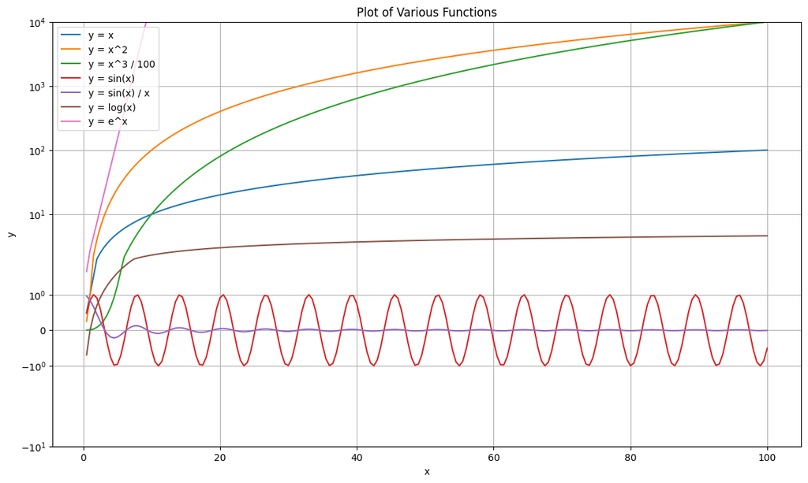

```python
import matplotlib.pyplot as plt
import numpy as np

x = np.arange(0.5, 100.5, 0.5)

y1 = x
y2 = x**2
y3 = (x**3) / 100
y4 = np.sin(x)
y5 = np.sin(x) / x
y6 = np.log(x)
y7 = np.exp(x)

# Plot
plt.figure(figsize=(14, 8))

plt.plot(x, y1, label="y = x")
plt.plot(x, y2, label="y = x^2")
plt.plot(x, y3, label="y = x^3 / 100")
plt.plot(x, y4, label="y = sin(x)")
plt.plot(x, y5, label="y = sin(x) / x")
plt.plot(x, y6, label="y = log(x)")
plt.plot(x, y7, label="y = e^x")

plt.title("Plot of Various Functions")
plt.xlabel("x")
plt.ylabel("y")
plt.ylim(-10, 10000)
plt.yscale('symlog')
plt.legend()
plt.grid(True)

plt.show()
```

### QUE 10 Using numpy generate a matrix of size 20X5 containing random numbers drawn uniformly from the range of 1 to 2. Using Pandas create a dataframe out of this matrix. Name the columns of the dataframe as “a”, “b”, “c”, “d”, “e”. Find the column with the highest standard deviation. Find the row with the lowest mean.

```python
import numpy as np
import pandas as pd

matrix = np.random.uniform(1, 2, size=(20, 5))

df = pd.DataFrame(matrix, columns=['a', 'b', 'c', 'd', 'e'])

column_with_highest_std = df.std().idxmax()
highest_std_value = df.std().max()

row_with_lowest_mean = df.mean(axis=1).idxmin()
lowest_mean_value = df.mean(axis=1).min()

# Print results
print("DataFrame:\n", df)
print("\nColumn with the highest standard deviation:", column_with_highest_std)
print("Highest standard deviation value:", highest_std_value)
print("\nRow with the lowest mean:", row_with_lowest_mean)
print("Lowest mean value:", lowest_mean_value)
```

```
DataFrame:
            a         b         c         d         e
0   1.429183  1.267777  1.789161  1.573349  1.658825
1   1.252307  1.220225  1.488375  1.737566  1.525240
2   1.032646  1.868552  1.064687  1.955824  1.025142
3   1.694450  1.082207  1.910677  1.464433  1.137524
4   1.340816  1.164825  1.170582  1.948108  1.445246
5   1.788802  1.639606  1.676426  1.131693  1.234184
6   1.786750  1.970766  1.262676  1.271569  1.472897
7   1.983840  1.268959  1.406972  1.891480  1.002921
8   1.039766  1.604072  1.907380  1.238857  1.469642
9   1.450465  1.472971  1.622520  1.469744  1.447468
10  1.474288  1.590867  1.537007  1.854136  1.049497
11  1.833317  1.843925  1.284908  1.462852  1.438538
12  1.218510  1.396797  1.044388  1.277822  1.816682
13  1.284562  1.818207  1.531599  1.879863  1.574780
14  1.029668  1.675420  1.044854  1.450597  1.929427
15  1.165204  1.389872  1.729860  1.882259  1.670943
16  1.258173  1.674608  1.296728  1.718429  1.954033
17  1.721393  1.862881  1.002104  1.717572  1.829588
18  1.040559  1.871598  1.256694  1.665292  1.800355
19  1.662665  1.092285  1.596322  1.549584  1.900321

Column with the highest standard deviation: e
Highest standard deviation value: 0.3071121736490656

Row with the lowest mean: 12
Lowest mean value: 1.3508397403687507
```

### QUE 11 Add a new column to the dataframe called “f” which is the sum of the columns “a”, “b”, “c”, “d”, “e”. Create another column called “g”. The value in the column “g” should be “LT8” if the value in the column “f” is less than 8 and “GT8” otherwise. Find the number of rows in the dataframe where the value in the column “g” is “LT8”. Find the standard deviation of the column “f” for the rows where the value in the column “g” is “LT8” and “GT8” respectively.

```python
import numpy as np
import pandas as pd

matrix = np.random.uniform(1, 2, size=(20, 5))

df = pd.DataFrame(matrix, columns=['a', 'b', 'c', 'd', 'e'])

df['f'] = df[['a', 'b', 'c', 'd', 'e']].sum(axis=1)

df['g'] = np.where(df['f'] < 8, 'LT8', 'GT8')

num_rows_lt8 = df[df['g'] == 'LT8'].shape[0]

std_f_lt8 = df[df['g'] == 'LT8']['f'].std()
std_f_gt8 = df[df['g'] == 'GT8']['f'].std()

print("DataFrame:\n", df)
print("\nNumber of rows where 'g' is 'LT8':", num_rows_lt8)
print("Standard deviation of 'f' where 'g' is 'LT8':", std_f_lt8)
print("Standard deviation of 'f' where 'g' is 'GT8':", std_f_gt8)
```

```
DataFrame:
            a         b         c         d         e         f    g
0   1.404240  1.321081  1.749851  1.412675  1.646096  7.533943  LT8
1   1.646450  1.888039  1.598692  1.502154  1.138871  7.774206  LT8
2   1.115738  1.154322  1.171848  1.637877  1.740981  6.820766  LT8
3   1.529992  1.829018  1.991263  1.820013  1.694882  8.865167  GT8
4   1.532493  1.448853  1.084392  1.399369  1.910135  7.375242  LT8
5   1.808023  1.216051  1.466608  1.816723  1.067385  7.374790  LT8
6   1.387393  1.851841  1.403898  1.077615  1.542534  7.263281  LT8
7   1.861742  1.590286  1.226279  1.384240  1.450123  7.512670  LT8
8   1.579266  1.759351  1.098874  1.889652  1.012310  7.339453  LT8
9   1.370052  1.027420  1.392974  1.525813  1.511681  6.827941  LT8
10  1.165628  1.645741  1.044778  1.761907  1.946644  7.564699  LT8
11  1.339769  1.517239  1.378910  1.006710  1.385875  6.628503  LT8
12  1.791720  1.595989  1.101260  1.847139  1.531085  7.867194  LT8
13  1.841723  1.580222  1.559688  1.105259  1.167360  7.254252  LT8
14  1.972025  1.228487  1.977452  1.531913  1.135789  7.845666  LT8
15  1.099302  1.208864  1.925637  1.414150  1.395434  7.043388  LT8
16  1.313206  1.147062  1.487851  1.130048  1.835480  6.913647  LT8
17  1.370397  1.374804  1.474006  1.444128  1.994858  7.658193  LT8
18  1.545381  1.088202  1.606877  1.151584  1.030938  6.422982  LT8
19  1.970742  1.773539  1.980109  1.477878  1.532258  8.734526  GT8

Number of rows where 'g' is 'LT8': 18
Standard deviation of 'f' where 'g' is 'LT8': 0.42277883302571556
Standard deviation of 'f' where 'g' is 'GT8': 0.09237746807125832
```

### QUE 13 Write a function to compute the argmin of a numpy array. The function should take a numpy array as input and return the index of the minimum element. You can use the np.argmin function to verify your solution.

```python
import numpy as np

def compute_argmin(arr):
    min_index = 0
    min_value = arr[0]

    for i in range(1, len(arr)):
        if arr[i] < min_value:
            min_value = arr[i]
            min_index = i

    return min_index

arr = np.random.rand(10)

argmin_custom = compute_argmin(arr)
print("Custom argmin:", argmin_custom)

argmin_np = np.argmin(arr)
print("Numpy argmin:", argmin_np)

print("Verification:", argmin_custom == argmin_np)
```

```
Custom argmin: 0
Numpy argmin: 0
Verification: True
```